# Tarea 2 Corregida: Análisis de Factores

Arantza Ivonne Pineda Sandoval_141194

# Introducción

Para este trabajo se utilizará la base de datos de tips de cambio de 80 economías diferentes. Los datos se extraen del archivo ‘est46114_s06_data’.

El objetivo es realizar un Análisis de Factores correspondiente a los datos bajo estudio.

Para comenzar la inspección de la base de datos, se importan algunas librerías útiles:

```r
knitr::opts_chunk$set(echo = TRUE)
library("tidyverse")
library("lubridate")
library(readxl)
```

A continuación se lee la base de datos y se realiza una inspección:

```r
tipo_de_cambio <- read_xls('est46114_s06_data.xls')
head(tipo_de_cambio)
```

```
## # A tibble: 6 x 81
##   Date                Canada Mexico Guatemala `El Salvador` Honduras
##   <dttm>               <dbl>  <dbl>     <dbl>         <dbl>    <dbl>
## 1 1970-01-01 00:00:00   1.11   9.38      7.53          20.2     14.4
## 2 1970-02-01 00:00:00   1.11   9.42      7.61          20.1     14.5
## 3 1970-03-01 00:00:00   1.11   9.45      7.78          20.2     14.5
## 4 1970-04-01 00:00:00   1.11   9.50      7.84          20.4     14.5
## 5 1970-05-01 00:00:00   1.12   9.51      7.74          20.5     14.5
## 6 1970-06-01 00:00:00   1.08   9.51      7.43          20.2     14.5
## # … with 75 more variables: Nicaragua <dbl>, `Costa Rica` <dbl>,
## #   Panama <dbl>, Jamaica <dbl>, `Dominican Rep` <dbl>,
## #   `Trin/Tobago` <dbl>, Colombia <dbl>, Venezuela <dbl>, Ecuador <dbl>,
## #   Peru <dbl>, Chile <dbl>, Brazil <dbl>, Paraguay <dbl>, Uruguay <dbl>,
## #   Argentina <dbl>, EU12 <dbl>, Sweden <dbl>, Norway <dbl>,
## #   Finland <dbl>, Denmark <dbl>, U.K. <dbl>, Ireland <dbl>,
## #   Luxembourg <dbl>, Netherlands <dbl>, France <dbl>, Germany <dbl>,
## #   Austria <dbl>, `Czech Rep` <dbl>, Hungary <dbl>, Switzerland <dbl>,
## #   Poland <dbl>, Russia <dbl>, Spain <dbl>, Portugal <dbl>, Italy <dbl>,
## #   Greece <dbl>, Turkey <dbl>, Syria <dbl>, Israel <dbl>, Jordan <dbl>,
## #   Kuwait <dbl>, `Saudi Arabia` <dbl>, India <dbl>, Pakistan <dbl>,
## #   Bangladesh <dbl>, `Sri Lanka` <dbl>, Thailand <dbl>, Malaysia <dbl>,
## #   Singapore <dbl>, Indonesia <dbl>, Philippines <dbl>, `China,PR` <dbl>,
## #   Korea <dbl>, `Hong Kong` <dbl>, Taiwan <dbl>, Japan <dbl>,
## #   Australia <dbl>, `New Zealand` <dbl>, Morocco <dbl>, Algeria <dbl>,
## #   Tunisia <dbl>, Egypt <dbl>, Cameroon <dbl>, Senegal <dbl>, `Sierra
## #   Leone` <dbl>, `Cote d'Ivoire` <dbl>, Ghana <dbl>, Nigeria <dbl>,
## #   Benin <dbl>, Congo <dbl>, Kenya <dbl>, Tanzania <dbl>,
## #   Mozambique <dbl>, `South Africa` <dbl>, Zambia <dbl>
```

```r
tail(tipo_de_cambio)
```

```
## # A tibble: 6 x 81
##   Date                Canada Mexico Guatemala `El Salvador` Honduras
##   <dttm>               <dbl>  <dbl>     <dbl>         <dbl>    <dbl>
## 1 2010-07-01 00:00:00   1.08   11.5      6.37          8.25     15.3
## 2 2010-08-01 00:00:00   1.08   11.4      6.27          8.25     15.2
## 3 2010-09-01 00:00:00   1.08   11.4      6.18          8.25     15.2
## 4 2010-10-01 00:00:00   1.08   11.4      6.11          8.26     15.2
## 5 2010-11-01 00:00:00   1.09   11.5      6.03          8.26     15.1
## 6 2010-12-01 00:00:00   1.09   11.5      5.95          8.26     15.1
## # … with 75 more variables: Nicaragua <dbl>, `Costa Rica` <dbl>,
## #   Panama <dbl>, Jamaica <dbl>, `Dominican Rep` <dbl>,
## #   `Trin/Tobago` <dbl>, Colombia <dbl>, Venezuela <dbl>, Ecuador <dbl>,
## #   Peru <dbl>, Chile <dbl>, Brazil <dbl>, Paraguay <dbl>, Uruguay <dbl>,
## #   Argentina <dbl>, EU12 <dbl>, Sweden <dbl>, Norway <dbl>,
## #   Finland <dbl>, Denmark <dbl>, U.K. <dbl>, Ireland <dbl>,
## #   Luxembourg <dbl>, Netherlands <dbl>, France <dbl>, Germany <dbl>,
## #   Austria <dbl>, `Czech Rep` <dbl>, Hungary <dbl>, Switzerland <dbl>,
## #   Poland <dbl>, Russia <dbl>, Spain <dbl>, Portugal <dbl>, Italy <dbl>,
## #   Greece <dbl>, Turkey <dbl>, Syria <dbl>, Israel <dbl>, Jordan <dbl>,
## #   Kuwait <dbl>, `Saudi Arabia` <dbl>, India <dbl>, Pakistan <dbl>,
## #   Bangladesh <dbl>, `Sri Lanka` <dbl>, Thailand <dbl>, Malaysia <dbl>,
## #   Singapore <dbl>, Indonesia <dbl>, Philippines <dbl>, `China,PR` <dbl>,
## #   Korea <dbl>, `Hong Kong` <dbl>, Taiwan <dbl>, Japan <dbl>,
## #   Australia <dbl>, `New Zealand` <dbl>, Morocco <dbl>, Algeria <dbl>,
## #   Tunisia <dbl>, Egypt <dbl>, Cameroon <dbl>, Senegal <dbl>, `Sierra
## #   Leone` <dbl>, `Cote d'Ivoire` <dbl>, Ghana <dbl>, Nigeria <dbl>,
## #   Benin <dbl>, Congo <dbl>, Kenya <dbl>, Tanzania <dbl>,
## #   Mozambique <dbl>, `South Africa` <dbl>, Zambia <dbl>
```

Se cargan los datos y se grafican para únicamente tres economías: Canadá, México y Zambia

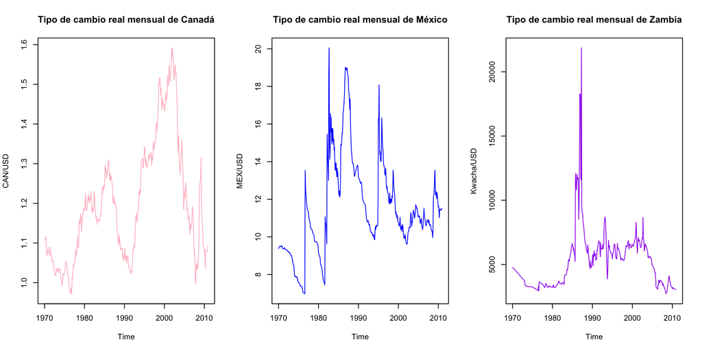

```r
tipo_de_cambio_canada <- ts(tipo_de_cambio$Canada,start = c(1970,01), frequency = 12)
tipo_de_cambio_zambia <- ts(tipo_de_cambio$Zambia,start = c(1970,01), frequency = 12)
tipo_de_cambio_mexico <- ts(tipo_de_cambio$Mexico,start = c(1970,01), frequency = 12)
par(mfrow = c(1,3))
plot(tipo_de_cambio_canada, main = "Tipo de cambio real mensual de Canadá", col = "pink", ylab="CAN/USD")
plot(tipo_de_cambio_mexico, main = "Tipo de cambio real mensual de México", col = "blue", ylab="MEX/USD")
plot(tipo_de_cambio_zambia, main = "Tipo de cambio real mensual de Zambia", col = "purple", ylab="Kwacha/USD")
```

## Tranformación de datos anualmente (para redefinición de Supuestos)

Similar al caso de Componentes Principales, se observa que existen ciertos supuestos que será necesario reefinir al modelo, de modo que se considere de forma anual. Para ello nuevamente se grafican las medias anuales:

```r
tipo_de_cambio_pais_promedio_anual <- function(x = tipo_de_cambio,pais = "Canada"){
  fecha <- as.Date(x$Date)
  tipo_de_cambio_mensual <-unname(unlist(x[pais]))

  datos_mensuales <- data_frame(fecha, tipo_de_cambio_mensual)

  datos_anuales <- datos_mensuales %>%
    group_by(year=floor_date(fecha, "year")) %>%
    summarize(media_anual = mean(tipo_de_cambio_mensual),
              desv_anual = sd(tipo_de_cambio_mensual))
  datos_anuales

}
canada_tc_prom_anual <- tipo_de_cambio_pais_promedio_anual(x = tipo_de_cambio,pais = "Canada")
```

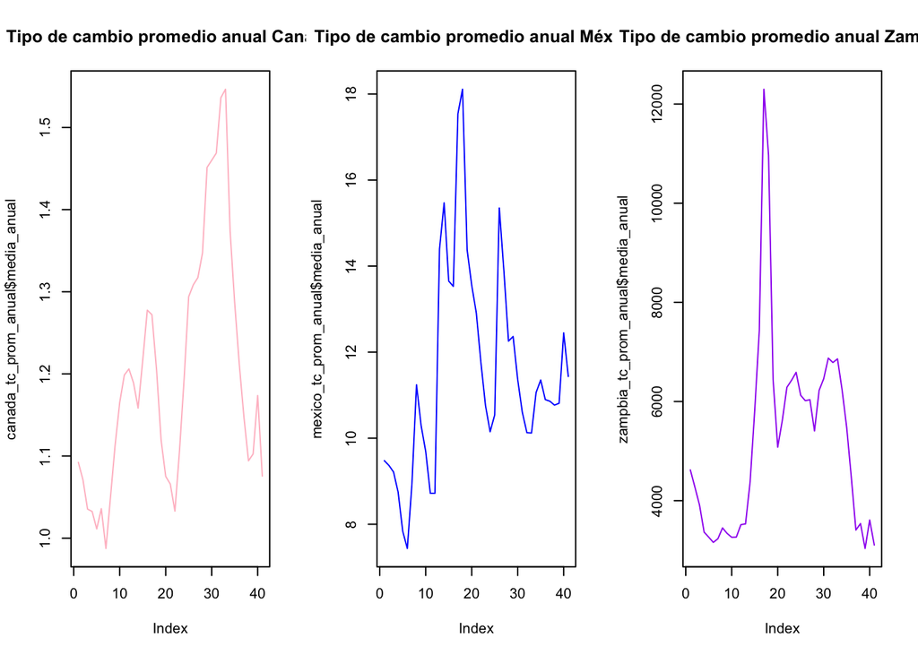

```r
mexico_tc_prom_anual <- tipo_de_cambio_pais_promedio_anual(x = tipo_de_cambio,pais = "Mexico")
zampbia_tc_prom_anual <- tipo_de_cambio_pais_promedio_anual(x = tipo_de_cambio,pais = "Zambia")

par(mfrow = c(1,3))
plot(canada_tc_prom_anual$media_anual, main="Tipo de cambio promedio anual Canadá", col = "pink", type = "l")
plot(mexico_tc_prom_anual$media_anual, main="Tipo de cambio promedio anual México", col = "blue", type = "l")
plot(zampbia_tc_prom_anual$media_anual, main="Tipo de cambio promedio anual Zambia", col = "purple", type ="l")
```

Se observa que las medias no son iguales y por lo tanto es adecuado asumir por el momento que una media promedio será de tipo anual.

Ahora se procede a estandarizar y centrar los datos alrededor de las medias previamente calculadas, esto para disminuir la variabilidad y realizar posteriormente inferencias adecuadas sin que exista ruido por las escalas particulares de cada país.

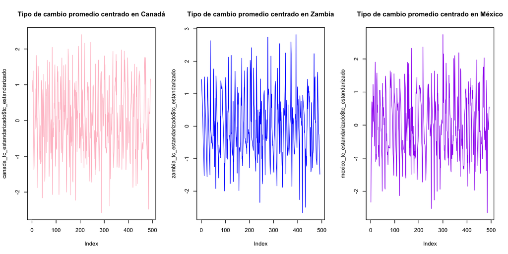

```r
tipo_de_cambio_pais_estandarizado <- function(x, pais){
    datos_mensuales <- x %>% select(Date,pais) %>% mutate(ano = year(Date)) %>% rename(tipo_de_cambio = pais)
    datos_anuales <- tipo_de_cambio_pais_promedio_anual(x,pais) %>% mutate(ano = year(year))

    datos_estandarizados <- datos_mensuales %>% left_join(datos_anuales, by=c("ano")) %>% mutate(tc_estandarizado = (tipo_de_cambio-media_anual) / desv_anual)

    datos_estandarizados %>% select(Date,ano, tc_estandarizado)
}
canada_tc_estandarizado <- tipo_de_cambio_pais_estandarizado(tipo_de_cambio, pais = "Canada")
zambia_tc_estandarizado <- tipo_de_cambio_pais_estandarizado(tipo_de_cambio, pais = "Zambia")
mexico_tc_estandarizado <- tipo_de_cambio_pais_estandarizado(tipo_de_cambio, pais = "Mexico")

par(mfrow = c(1,3))
plot(canada_tc_estandarizado$tc_estandarizado, main="Tipo de cambio promedio centrado en Canadá", type ="l", col= "pink")
plot(zambia_tc_estandarizado$tc_estandarizado, main="Tipo de cambio promedio centrado en Zambia",  type = "l",col= "blue")
plot(mexico_tc_estandarizado$tc_estandarizado, main="Tipo de cambio promedio centrado en México", type = "l", col= "purple")
```

De manera similar al caso sencillo con las 3 economías, se procede a estandarizar la base de datos para los 80 países. A esta nueva base se la llamará matriz de diseño y será aquella con la cual se realizará el análisis de factores.

```r
paises_de_interes <- names(tipo_de_cambio)[-1]

lista_paises_estandarizados <- lapply(paises_de_interes, tipo_de_cambio_pais_estandarizado, x = tipo_de_cambio)

names(lista_paises_estandarizados) <- names(tipo_de_cambio)[-1]

df_tipo_de_cambio_estandarizados <- bind_rows(lista_paises_estandarizados, .id = "column_label") %>%
  spread(column_label,tc_estandarizado)
```

```r
df_tipo_de_cambio_estandarizados_2010 <- df_tipo_de_cambio_estandarizados %>%
  filter(ano == 2010) %>% select(-Date, -ano)

matriz_de_diseno <- df_tipo_de_cambio_estandarizados  %>% select(-Date, -ano)
```

# Modelo de Análisis de Factores (con MCMC factanal)

En esta sección se procede a aplicar el comando ‘MCMCfactanal’ referente a Markov Chain Monte Carlo for Normal Theory Factor Analysis Model para la simulación. Se realizarán 1000 simulaciones indicando que se trata de un solo factor k=1.El periodo de calentamiento es de 500 cadenas y se ingresan los parámetros correspondientes.

```r
library(MCMCpack)
n <-  nrow(matriz_de_diseno)
p <- ncol(matriz_de_diseno)
k <- 1

data.sim <- matriz_de_diseno

M.sim <- 1000
M.burn <- 500

posterior.data.sim <- MCMCfactanal(~.,

                          factors=k,
                          verbose=0, store.scores=FALSE,
                          a0=1,
                          b0=0.15,
                          data=data.sim,
                          burnin=M.burn,
                          mcmc=M.sim,
                          thin=20)
```

Una vez realizada la simulación, se obtienen estadísticas resultantes que incluyen:

a)Valores de la matriz de Lambda b)Valores de la matriz de Sigma

```r
summary(posterior.data.sim)
```

```
##
## Iterations = 501:1481
## Thinning interval = 20
## Number of chains = 1
## Sample size per chain = 50
##
## 1. Empirical mean and standard deviation for each variable,
##    plus standard error of the mean:
##
##                              Mean       SD  Naive SE Time-series SE
## LambdaAlgeria_1         -0.391735 0.074505 0.0105366      0.0105366
## LambdaArgentina_1       -0.245131 0.077471 0.0109560      0.0042548
## LambdaAustralia_1       -0.562098 0.070977 0.0100376      0.0100376
## LambdaAustria_1         -1.216242 0.057183 0.0080868      0.0345079
## LambdaBangladesh_1      -0.432705 0.066307 0.0093773      0.0093773
## LambdaBenin_1           -1.080438 0.051745 0.0073179      0.0220636
## LambdaBrazil_1          -0.100463 0.068144 0.0096370      0.0119914
## LambdaCameroon_1        -1.164068 0.051642 0.0073033      0.0188720
## LambdaCanada_1          -0.306236 0.070857 0.0100207      0.0078823
## LambdaChile_1           -0.299591 0.060728 0.0085882      0.0085882
## Lambda`China,PR`_1      -0.079984 0.058355 0.0082526      0.0066827
## LambdaColombia_1        -0.129136 0.054092 0.0076498      0.0062537
## LambdaCongo_1           -0.829281 0.063348 0.0089587      0.0112175
## Lambda`Costa Rica`_1    -0.054689 0.071139 0.0100606      0.0100606
## Lambda`Cote d'Ivoire`_1 -1.132162 0.058777 0.0083124      0.0234525
## Lambda`Czech Rep`_1     -0.766270 0.064200 0.0090793      0.0184074
## LambdaDenmark_1         -1.225059 0.054117 0.0076534      0.0251837
## Lambda`Dominican Rep`_1 -0.023733 0.073369 0.0103759      0.0075507
## LambdaEcuador_1          0.086972 0.085092 0.0120338      0.0120338
## LambdaEgypt_1           -0.101307 0.073788 0.0104351      0.0104351
## Lambda`El Salvador`_1    0.047587 0.067865 0.0095975      0.0095975
## LambdaEU12_1            -1.216774 0.055479 0.0078458      0.0254588
## LambdaFinland_1         -1.140509 0.054808 0.0077510      0.0217255
## LambdaFrance_1          -1.222564 0.055596 0.0078625      0.0322952
## LambdaGermany_1         -1.222606 0.053469 0.0075617      0.0296252
## LambdaGhana_1           -0.107802 0.076207 0.0107773      0.0107773
## LambdaGreece_1          -1.035293 0.057329 0.0081075      0.0221079
## LambdaGuatemala_1        0.070457 0.083447 0.0118011      0.0118011
## LambdaHonduras_1         0.131042 0.074701 0.0105644      0.0105644
## Lambda`Hong Kong`_1      0.090061 0.060568 0.0085656      0.0085656
```

[output cut: 279 more lines]

```
## PsiSpain                 0.06540  0.0721327  0.07851  0.082579  0.0909251
## Psi`Sri Lanka`           0.83975  0.9115304  0.97148  1.019771  1.1012187
## PsiSweden                0.24273  0.2660202  0.28654  0.309005  0.3381872
## PsiSwitzerland           0.34467  0.3846432  0.41128  0.437425  0.4685390
## PsiSyria                 0.86420  0.9249049  0.98875  1.038427  1.1219897
## PsiTaiwan                0.81451  0.8875152  0.92734  0.989183  1.0910663
## PsiTanzania              0.85855  0.9284507  0.97443  1.029872  1.1505275
## PsiThailand              0.59463  0.6409946  0.67167  0.713567  0.7752774
## Psi`Trin/Tobago`         0.82578  0.9184540  0.96733  0.995805  1.1015382
## PsiTunisia               0.09053  0.0973999  0.10290  0.108377  0.1204048
## PsiTurkey                0.70927  0.7734624  0.80821  0.846162  0.9087506
## PsiU.K.                  0.38639  0.4399807  0.45666  0.476143  0.5094843
## PsiUruguay               0.85488  0.9133630  0.97107  1.018076  1.1159263
## PsiVenezuela             0.84908  0.9518187  1.02106  1.062007  1.1645106
## PsiZambia                0.85675  0.9463624  1.00920  1.042472  1.1836793
```

Para una mejor visualización y manejo de los resultados, se transforma a un formato de dataframe:

```r
df_simulaciones <- as_data_frame(posterior.data.sim)
head(df_simulaciones)
```

```
## # A tibble: 6 x 160
##   LambdaAlgeria_1 LambdaArgentina… LambdaAustralia… LambdaAustria_1
##             <dbl>            <dbl>            <dbl>           <dbl>
## 1          -0.403          -0.166            -0.489           -1.10
## 2          -0.363          -0.275            -0.652           -1.14
## 3          -0.287          -0.375            -0.563           -1.13
## 4          -0.359          -0.0738           -0.559           -1.14
## 5          -0.348          -0.225            -0.542           -1.12
## 6          -0.416          -0.336            -0.443           -1.15
## # … with 156 more variables: LambdaBangladesh_1 <dbl>,
## #   LambdaBenin_1 <dbl>, LambdaBrazil_1 <dbl>, LambdaCameroon_1 <dbl>,
## #   LambdaCanada_1 <dbl>, LambdaChile_1 <dbl>,
## #   `Lambda\`China,PR\`_1` <dbl>, LambdaColombia_1 <dbl>,
## #   LambdaCongo_1 <dbl>, `Lambda\`Costa Rica\`_1` <dbl>, `Lambda\`Cote
## #   d'Ivoire\`_1` <dbl>, `Lambda\`Czech Rep\`_1` <dbl>,
## #   LambdaDenmark_1 <dbl>, `Lambda\`Dominican Rep\`_1` <dbl>,
## #   LambdaEcuador_1 <dbl>, LambdaEgypt_1 <dbl>, `Lambda\`El
## #   Salvador\`_1` <dbl>, LambdaEU12_1 <dbl>, LambdaFinland_1 <dbl>,
## #   LambdaFrance_1 <dbl>, LambdaGermany_1 <dbl>, LambdaGhana_1 <dbl>,
## #   LambdaGreece_1 <dbl>, LambdaGuatemala_1 <dbl>, LambdaHonduras_1 <dbl>,
## #   `Lambda\`Hong Kong\`_1` <dbl>, LambdaHungary_1 <dbl>,
## #   LambdaIndia_1 <dbl>, LambdaIndonesia_1 <dbl>, LambdaIreland_1 <dbl>,
## #   LambdaIsrael_1 <dbl>, LambdaItaly_1 <dbl>, LambdaJamaica_1 <dbl>,
## #   LambdaJapan_1 <dbl>, LambdaJordan_1 <dbl>, LambdaKenya_1 <dbl>,
## #   LambdaKorea_1 <dbl>, LambdaKuwait_1 <dbl>, LambdaLuxembourg_1 <dbl>,
## #   LambdaMalaysia_1 <dbl>, LambdaMexico_1 <dbl>, LambdaMorocco_1 <dbl>,
## #   LambdaMozambique_1 <dbl>, LambdaNetherlands_1 <dbl>, `Lambda\`New
## #   Zealand\`_1` <dbl>, LambdaNicaragua_1 <dbl>, LambdaNigeria_1 <dbl>,
## #   LambdaNorway_1 <dbl>, LambdaPakistan_1 <dbl>, LambdaPanama_1 <dbl>,
## #   LambdaParaguay_1 <dbl>, LambdaPeru_1 <dbl>, LambdaPhilippines_1 <dbl>,
## #   LambdaPoland_1 <dbl>, LambdaPortugal_1 <dbl>, LambdaRussia_1 <dbl>,
## #   `Lambda\`Saudi Arabia\`_1` <dbl>, LambdaSenegal_1 <dbl>,
## #   `Lambda\`Sierra Leone\`_1` <dbl>, LambdaSingapore_1 <dbl>,
## #   `Lambda\`South Africa\`_1` <dbl>, LambdaSpain_1 <dbl>, `Lambda\`Sri
## #   Lanka\`_1` <dbl>, LambdaSweden_1 <dbl>, LambdaSwitzerland_1 <dbl>,
## #   LambdaSyria_1 <dbl>, LambdaTaiwan_1 <dbl>, LambdaTanzania_1 <dbl>,
## #   LambdaThailand_1 <dbl>, `Lambda\`Trin/Tobago\`_1` <dbl>,
## #   LambdaTunisia_1 <dbl>, LambdaTurkey_1 <dbl>, LambdaU.K._1 <dbl>,
## #   LambdaUruguay_1 <dbl>, LambdaVenezuela_1 <dbl>, LambdaZambia_1 <dbl>,
## #   PsiAlgeria <dbl>, PsiArgentina <dbl>, PsiAustralia <dbl>,
## #   PsiAustria <dbl>, PsiBangladesh <dbl>, PsiBenin <dbl>,
## #   PsiBrazil <dbl>, PsiCameroon <dbl>, PsiCanada <dbl>, PsiChile <dbl>,
## #   `Psi\`China,PR\`` <dbl>, PsiColombia <dbl>, PsiCongo <dbl>,
## #   `Psi\`Costa Rica\`` <dbl>, `Psi\`Cote d'Ivoire\`` <dbl>, `Psi\`Czech
## #   Rep\`` <dbl>, PsiDenmark <dbl>, `Psi\`Dominican Rep\`` <dbl>,
## #   PsiEcuador <dbl>, PsiEgypt <dbl>, `Psi\`El Salvador\`` <dbl>,
## #   PsiEU12 <dbl>, PsiFinland <dbl>, PsiFrance <dbl>, …
```

Se acomodan los datos en formato columnar de modo que sea más fácil trabajar con los valores de Lambdas y Sigmas posteriormente:

```r
lambdas <- dplyr::select(df_simulaciones, starts_with("Lamb")) %>% summarise_all("mean")  %>% gather("pais","lambda", 1:80)
sigma <- dplyr::select(df_simulaciones, starts_with("Psi")) %>% summarise_all("mean")  %>% gather("pais","psi", 1:80)

resultados_promedio <- cbind(lambdas,sigma)
names(resultados_promedio) <- c("pais_lambda", "lambda", "pais_sigma", "sigma")
resultados_promedio <- resultados_promedio %>% dplyr::select(-pais_lambda,-pais_sigma)
pais <- names(data.sim)
resultados_promedio <- cbind(pais, resultados_promedio)
head(resultados_promedio)
```

```
##         pais     lambda     sigma
## 1    Algeria -0.3917352 0.8993460
## 2  Argentina -0.2451315 0.9694754
## 3  Australia -0.5620976 0.7898048
## 4    Austria -1.2162422 0.0249438
## 5 Bangladesh -0.4327046 0.8842692
## 6      Benin -1.0804383 0.2237412
```

Ahora, se procede a encontrar las Varianzas marginales correspondientes a cada país. Esto para tener un análisis tabular en el que se muestren los tres elementos importantes por país:

a)Lambdas b)Sigmas c)Varianzas Margianles

```r
resultados_final<-resultados_promedio %>% mutate("varianza_marginal" = (lambda * lambda) + sigma)
resultados_final
```

```
##             pais       lambda      sigma varianza_marginal
## 1        Algeria -0.391735164 0.89934604         1.0528025
## 2      Argentina -0.245131486 0.96947538         1.0295648
## 3      Australia -0.562097581 0.78980483         1.1057585
## 4        Austria -1.216242204 0.02494380         1.5041889
## 5     Bangladesh -0.432704559 0.88426915         1.0715024
## 6          Benin -1.080438260 0.22374124         1.3910881
## 7         Brazil -0.100462685 0.98263857         0.9927313
## 8       Cameroon -1.164068055 0.10837543         1.4634299
## 9         Canada -0.306235529 0.95135492         1.0451351
## 10         Chile -0.299590719 0.93874353         1.0284981
## 11      China,PR -0.079984425 1.00331939         1.0097169
## 12      Colombia -0.129136456 0.99462707         1.0113033
## 13         Congo -0.829281364 0.54872509         1.2364327
## 14    Costa Rica -0.054688939 1.00361548         1.0066064
```

[output cut: 66 more lines]

# Comentarios del Resultado de Análisis de Factores

## Sigmas

De la tabla anterior se observa lo siguiente:

Las sigmas corresponden a las varianzas idiosincráticas de los países y se observa que sus valores son positivos. Esto da indicios de que se trata de una matriz de sigmas positiva definida.

```r
resultados_final %>% arrange(sigma) %>% head(3)
```

```
##         pais    lambda      sigma varianza_marginal
## 1    Denmark -1.225059 0.01636931          1.517140
## 2     France -1.222564 0.01696173          1.511625
## 3 Luxembourg -1.221762 0.01920215          1.511905
```

Al observar los países con menor varianza idiosincrática, se descubre que son: Dinamarca, Francia y Luxemburgo. Esto implica que estas son economías con poca volatilidad.

```r
resultados_final %>% arrange(sigma) %>% tail(3)
```

```
##             pais      lambda    sigma varianza_marginal
## 78     Hong Kong  0.09006057 1.010843          1.018954
## 79 Dominican Rep -0.02373291 1.017127          1.017690
## 80  Sierra Leone  0.06586979 1.020832          1.025171
```

## Lambdas

Ahora se observan las Lambdas resultantes, que corresponden a la matriz de Lambda.

```r
resultados_final %>% arrange(lambda) %>% head(3)
```

```
##      pais    lambda      sigma varianza_marginal
## 1 Denmark -1.225059 0.01636931          1.517140
## 2 Germany -1.222606 0.02073694          1.515503
## 3  France -1.222564 0.01696173          1.511625
```

```r
resultados_final %>% arrange(lambda) %>% tail(3)
```

```
##         pais     lambda     sigma varianza_marginal
## 78 Hong Kong 0.09006057 1.0108429          1.018954
## 79  Honduras 0.13104184 0.9907327          1.007905
## 80    Mexico 0.16940174 0.9834948          1.012192
```

De modo inverso, los países de :Hong Kong, Honduras y México tienen pesos positivos en el factor 1, es decir, que están relacionados de manera positiva en el factor 1.

## Varianza Marginal

Ahora lo que se busca es tener un indicador integrador que pemita observar la información que proporcionan las cargas del factor k más la información correspondiente a los elementos de la diagonal de la matriz sigma. Para ello se realizaron los cálculos correspondientes previamente y se muestran las varianzas marginales resultantes:

```r
resultados_final %>% arrange(varianza_marginal) %>% head(3)
```

```
##      pais      lambda     sigma varianza_marginal
## 1    Peru -0.08788823 0.9832555         0.9909798
## 2 Ecuador  0.08697191 0.9835279         0.9910920
## 3 Jamaica -0.14234572 0.9719555         0.9922178
```

Los países de Perú, Ecuador y Jamaica son los países con menor varianza marginal.

```r
resultados_final %>% arrange(varianza_marginal) %>% tail(3)
```

```
##          pais    lambda      sigma varianza_marginal
## 78 Luxembourg -1.221762 0.01920215          1.511905
## 79    Germany -1.222606 0.02073694          1.515503
## 80    Denmark -1.225059 0.01636931          1.517140
```

Mienras que Luxemburgo, Alemania y Dinamarca resultaron ser los países con mayor varianza marginal.